# DATS 6103 - Fall 2020 - Daniel Bernal

# Individual Project #3 - Impact of COVID-19 on Air Transportation in the US

# Introduction

For project #3 I selected to analyze the impact of COVID-19 on commercial air transportation within the US. Air transportation is a sector that has been forced to change and to modify its operations in 2020. Just like any other industry, they have suffered significant effects due to the reduction of operations and the restrictions imposed by the authorities. To identify impacts in domestic transportation, this project will analyze a [dataset](https://www.kaggle.com/akulbahl/covid19-airline-flight-delays-and-cancellations/tasks) found in Kaggle that includes flight data from January to June.

# Import Python Packages

```python
import pandas as pd
import matplotlib.pyplot as plt
import plotly.graph_objects as pg
import plotly.express as px
import warnings
warnings.filterwarnings('ignore')
```

# 1. Read the CSV Files

```python
df = pd.read_csv('jantojun2020.csv')
airports = pd.read_csv('https://raw.githubusercontent.com/plotly/datasets/master/2011_february_us_airport_traffic.csv')
va = pd.read_csv('virginia.csv')
md = pd.read_csv('maryland.csv')
```

# 2. Data Cleaning

## Drop Columns

```python
df = df.drop(['YEAR','DAY_OF_MONTH','MKT_CARRIER_FL_NUM','QUARTER','DAY_OF_WEEK',
              'TAIL_NUM','CRS_DEP_TIME','DEP_TIME','DEP_DELAY','DEP_DELAY_NEW','DEP_DEL15',
              'DEP_DELAY_GROUP','DEP_TIME_BLK','TAXI_OUT','WHEELS_OFF','WHEELS_ON','TAXI_IN','CRS_ARR_TIME','ARR_TIME',
              'ARR_DELAY','ARR_DELAY_NEW','ARR_DEL15','ARR_DELAY_GROUP','ARR_TIME_BLK',
              'CRS_ELAPSED_TIME','ACTUAL_ELAPSED_TIME','AIR_TIME','DISTANCE_GROUP','CARRIER_DELAY','WEATHER_DELAY', 'NAS_DELAY',
               'SECURITY_DELAY', 'LATE_AIRCRAFT_DELAY','CANCELLATION_CODE','FL_DATE'], axis=1)
```

## Rename Columns

```python
df = df.rename(columns={'MONTH':'month', 'MKT_UNIQUE_CARRIER':'carrier', 'ORIGIN':'origin',
       'ORIGIN_CITY_NAME': 'origin_city', 'ORIGIN_STATE_ABR':'orig_st_abr', 'ORIGIN_STATE_NM':'orig_st_name', 'DEST':'destination',
       'DEST_CITY_NAME':'dest_city', 'DEST_STATE_ABR':'dest_st_abr', 'DEST_STATE_NM':'dest_st_name', 'CANCELLED':'cancelled',
        'DISTANCE':'miles'})
```

Adding a flight count column and creating a new dataframe for Virginia and Maryland only.

```python
df['fl_count'] = 1
states = [va,md]
data = pd.concat(states)

# Size of the original dataframe
df.shape
```

```
(2745847, 13)
```

# 3. Analysis

## 3.1 Total Domestic Flights Scheduled in the US from Jan to Jun

Findings:

- Three states, California, Texas, and Florida, had the most scheduled domestic flights.
- States such as Illinois, Georgia, North Carolina, New York, Virginia, and Colorado, had slightly over 100k scheduled flights.

```python
# From the original dataframe, we group by the state where each flight departed, and drop unneeded columns
state_1 = df.groupby(['orig_st_abr']).sum().reset_index()
state_1 = state_1.drop(['month','miles','cancelled'], axis=1)

# Used a choropleth to graph the total amount of domestic flights scheduled the first semester of 2020
fig =pg.Figure(data=pg.Choropleth(
    locations = state_1['orig_st_abr'],
    z = state_1[('fl_count')],
    text = state_1['orig_st_abr'],
    locationmode='USA-states',
    autocolorscale=True,
    marker_line_color='rgb(255,255,255)',
    marker_line_width=2,
    colorbar_tickprefix = '',
    colorbar_title = 'Total Flights'))
fig.update_layout(title_text = 'Total Flights in the US',
    geo = dict(
        showframe=False,
        showcoastlines=True,
        showlakes=False,
        lakecolor='rgb(95,145,237)',
        projection_type='albers usa'))
fig.show()
```

[interactive chart not shown]

## 3.2 Comparing Total Scheduled with Total Cancelled Flights by Month

Findings:

- As expected, the amount of flights scheduled tend to be steady and high from January to March, while the cancellations remain at very low levels,
- March is definetely the turning point since this is the month where the majority of states started the quarantine, and the majority of companies sent their employees to work remotly.
- March and April presented the highest number of flights cancelled.
- After March, scheduled flights decreased by almost half.

```python
# Group the original dataframe by month
month_1 = df.groupby(['month']).sum().reset_index()

# Used a bar chart with a drop down menu to illustrate flight count and the cancelled ones per month
plot = pg.Figure(data=[pg.Bar(name='Total Flights', x=month_1['month'], y=month_1['fl_count']),
    pg.Bar( name='Total Flights Cancelled', x=month_1['month'], y=month_1['cancelled'])])

# Adding a dropdown menu
plot.update_layout(
    updatemenus=[dict(active=0,
            buttons=list([
                dict(label='Totals',
                     method='update',
                     args=[{'visible': [True, True]},
                           {'title': 'Totals'}]),
                dict(label='Total Flights',
                     method='update',
                     args=[{'visible': [True, False]},
                           {'title': 'Total Flights'}]),
                dict(label='Total Flights Cancelled',
                     method='update',
                     args=[{'visible': [False, True]},
                           {'title': 'Total Flights Cancelled'}])]))])

plot.show()
```

[interactive chart not shown]

## 3.3 Comparing Total Scheduled with Total Cancelled Flights per Carrier

The domestic airlines included in this dataset are:

- AA: American Airlines
- AS: Alaska Airlines
- B6: JetBlue
- DL: Delta Air Lines
- F9: Frontier Airlines
- G4: Allegiant Air
- HA: Hawaiian Airlines
- NK: Spirit Airlines
- UA: United Airlines
- WN: Southwest Airlines

Findings:

- American, Delta, United, and Southwest were the dominant domestic airlines in terms of total flights.
- In terms of cancelled flights, Southwest has a surprising high amount of cancelled flights with respect to total flights.

```python
# Grouped by domestic airline to illustrate the flight count and cancelled flights
carrier_1 = df.groupby(['carrier']).sum().reset_index()

# Used a bar chart with a drop down menu to illustrate flight count and the cancelled ones by airline
plot = pg.Figure(data=[pg.Bar(
    name='Total Flights per Carrier',
    x=carrier_1['carrier'],
    y=carrier_1['fl_count']),
    pg.Bar(name='Total Flights Cancelled per Carrier',
    x=carrier_1['carrier'],
    y=carrier_1['cancelled'])])

# Adding a dropdown menu
plot.update_layout(
    updatemenus=[
        dict(
            active=0,
            buttons=list([
                dict(label='Totals',
                     method='update',
                     args=[{'visible': [True, True]},
                           {'title': 'Totals'}]),
                dict(label='Total Flights',
                     method='update',
                     args=[{'visible': [True, False]},
                           {'title': 'Total Flights per Carrier'}]),
                dict(label='Total Flights Cancelled',
                     method='update',
                     args=[{'visible': [False, True]},
                           {'title': 'Total Flights Cancelled per Carrier'}])]))])

plot.show()
```

[interactive chart not shown]

## 3.3.1 Changes Over Time for each Airline

Findings:

- As we saw previously that April is the month with the highest number of flights cancelled, we see that from the four major airlines, American and Southwest presented the highest number of cancelled flights in April.

## Total Scheduled Flights

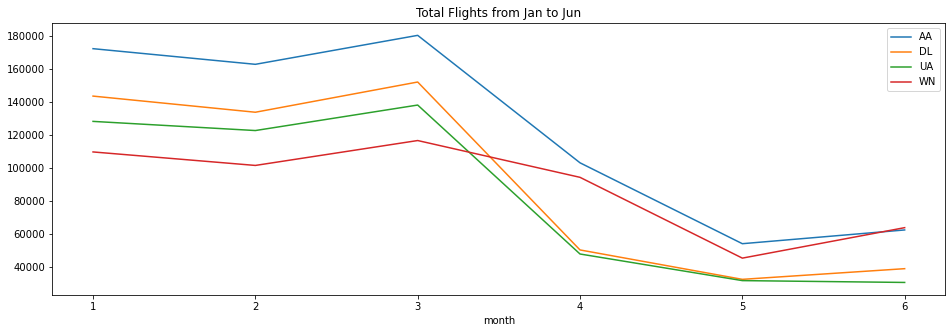

```python
# Creating a pivot table
carrier_2 = df.groupby(['carrier','month']).sum().reset_index()
carrier_2 = carrier_2.pivot(index='carrier', columns='month', values='fl_count')

#Defining a graph where we can pass the abbreviation of one or all of the airline to display the data
def carrier_totals(carrier):
    carrier_2.loc[carrier].plot(legend=True, figsize=(16,5), title='Total Flights from Jan to Jun')

# One can visualize as many as necessary
carrier_totals('AA')
#carrier_totals('AS')
#carrier_totals('B6')
carrier_totals('DL')
#carrier_totals('F9')
#carrier_totals('G4')
#carrier_totals('HA')
#carrier_totals('NK')
carrier_totals('UA')
carrier_totals('WN')

plt.show()
```

## Total Flights Cancelled

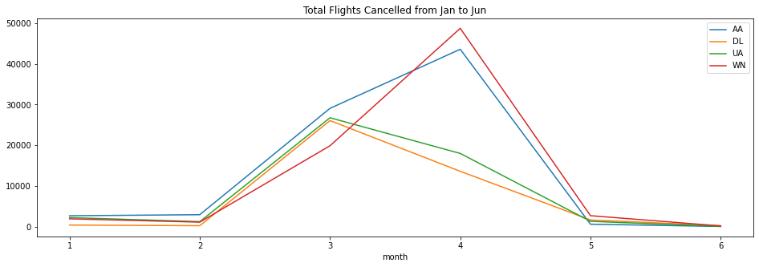

```python
# Creating a pivot table
carrier_3 = df.groupby(['carrier','month']).sum().reset_index()
carrier_3 = carrier_3.pivot(index='carrier', columns='month', values='cancelled')

#Defining a graph where we can pass the abbreviation of one or all of the airline to display the data for cancelled flights
def carrier_cancelled(carrier):
    carrier_3.loc[carrier].plot(legend=True, figsize=(16,5), title='Total Flights Cancelled from Jan to Jun')

carrier_cancelled('AA')
#carrier_cancelled('AS')
#carrier_cancelled('B6')
carrier_cancelled('DL')
#carrier_cancelled('F9')
#carrier_cancelled('G4')
#carrier_cancelled('HA')
#carrier_cancelled('NK')
carrier_cancelled('UA')
carrier_cancelled('WN')

plt.show()
```

## 3.4 Most Frequent Departures by Airline

Airlines:

- AA: American Airlines
- AS: Alaska Airlines
- B6: JetBlue
- DL: Delta Air Lines
- F9: Frontier Airlines
- G4: Allegiant Air
- HA: Hawaiian Airlines
- NK: Spirit Airlines
- UA: United Airlines
- WN: Southwest Airlines

You can replace the abbreviation to display the relevant data for any particular airline.

```python
# Indicate the Airline
airline = 'AA'


# Creating a dataframe to display the top ten city departures for a specific airline
carrier_4 = df.groupby(['carrier','origin_city']).sum().reset_index().sort_values(by='fl_count', ascending=False)
top_ten_cities = carrier_4.loc[(carrier_4['carrier'] == airline)].reset_index(drop=True)
top_ten_cities = top_ten_cities.drop(['month','miles'], axis=1).sort_values(by='fl_count', ascending=False)

# Renaming the columns of the dataframe
top_ten_cities = top_ten_cities.rename(columns={'carrier':'Airline','origin_city': 'Origin', 'cancelled': 'Cancelled Flights', 'fl_count':'Total Flights'})

# Adding a new column to display the percentage of cancelled flights for the first semester of 2020
top_ten_cities['Percentage of Flights Cancelled'] = (top_ten_cities['Cancelled Flights']/top_ten_cities['Total Flights'])*100
top_ten_cities.index += 1
top_ten_cities = top_ten_cities.loc[:10]

# Quering the original dataframe to graph the data
carrier_6 = df.groupby(['carrier','orig_st_abr']).sum().reset_index()
carrier_6 = carrier_6.drop(['month','miles','cancelled'], axis=1)
carrier_6 = carrier_6.pivot(index='orig_st_abr', columns='carrier', values='fl_count').reset_index()
carrier_6.columns.name = None

# Definning a function to illustrate a choropleth for a specific airline
def us_map(carrier):
    fig =pg.Figure(data=pg.Choropleth(
        locations = carrier_6['orig_st_abr'],
        z = carrier_6[str(carrier)],
        text = carrier_6['orig_st_abr'],
        locationmode='USA-states',
        autocolorscale=True,
        marker_line_color='rgb(255,255,255)',
        marker_line_width=2,
        colorbar_tickprefix = '',
        colorbar_title = 'Flights for ' + str(carrier)))

    fig.update_layout(
        title_text = 'Total Flights for ' + str(carrier),
        geo = dict(
            showframe=False,
            showcoastlines=True,
            showlakes=False,
            lakecolor='rgb(95,145,237)',
            projection_type='albers usa'))
    fig.show()

# Map
us_map(airline)
# Top ten table
top_ten_cities
```

[interactive chart not shown]

|  | Airline | Origin | Cancelled Flights | Total Flights | Percentage of Flights Cancelled |
| --- | --- | --- | --- | --- | --- |
| 1 | AA | Dallas/Fort Worth, TX | 10324 | 101448 | 10.176642 |
| 2 | AA | Charlotte, NC | 10162 | 90833 | 11.187564 |
| 3 | AA | Chicago, IL | 5807 | 51906 | 11.187531 |
| 4 | AA | Philadelphia, PA | 4563 | 38780 | 11.766374 |
| 5 | AA | Phoenix, AZ | 2907 | 31324 | 9.280424 |
| 6 | AA | Washington, DC | 3265 | 28428 | 11.485155 |
| 7 | AA | Miami, FL | 2407 | 26317 | 9.146179 |
| 8 | AA | New York, NY | 2532 | 20687 | 12.239571 |
| 9 | AA | Los Angeles, CA | 1513 | 19593 | 7.722146 |
| 10 | AA | Boston, MA | 1082 | 9203 | 11.757036 |

## 3.5 Top Cancelled Destinations Nationwide

Findings:

- Chicago represents the top destination for domestic flights.
- The rest of the cities seem to have roughly similar numbers.

```python
# Grouping by destination
topten_dest = df.groupby(['dest_city']).sum().reset_index()

# Dropping unneeded columns and sorting by cancelled flights
topten_dest = topten_dest.drop(['month','miles','fl_count'], axis=1).sort_values(by='cancelled', ascending=False)

# Selecting the top ten cities
topten_dest = topten_dest.iloc[:10]

# Using a bar chart to visualize the top ten cities
top1 = px.bar(topten_dest, x='dest_city', y='cancelled', title='Top Ten Destinations with Cancelled Flights',
            labels=dict(dest_city='City', cancelled='Cancelled'))

top1.update_traces(marker_color='rgb(158,202,225)', marker_line_color='rgb(8,48,107)',
                  marker_line_width=1.5, opacity=0.6)
top1.show()
```

[interactive chart not shown]

## 3.6 Destinations for Virginia and Maryland

To analyze this two states, it was necessary to conduct a multistep process to get the needed data. Process is as follows:

1. Downloaded the longitude and latitude for the airports in the US.
2. Separately created a csv for MD and VA, we read these CSVs and concatenated them.
3. Selected the needed columns from the concatenated dataframe.
4. Selected the needed columns with the longitude and latitude values.
5. Merge dataframes on destination so we can have the longitude and latitude only for the destination of that flight.
6. Remove duplicates to have only one entry per flight for each state.

```python
# Note that step 1 and two were performed at the beginning of this workbook

# Step 3
va_md = data[['origin','destination','month', 'miles', 'carrier', 'orig_st_abr', 'origin_city', 'dest_city', 'dest_st_abr']]

# Step 4
apid = airports[['iata','lat','long']]
apid = apid.rename(columns={'iata':'destination'})

# Step 5
va_md = pd.merge(va_md, apid, how='left', on=['destination'])
va_md = va_md.rename(columns={'lat':'lat_end', 'long': 'long_end'})

#Step 6
no_duplicates = va_md.drop_duplicates(keep='first', inplace=False).dropna()
va_nodup = no_duplicates.loc[(no_duplicates['orig_st_abr'] == 'VA')]
md_nodup = no_duplicates.loc[(no_duplicates['orig_st_abr'] == 'MD')]
```

There are a total of 12 airports in VA and MD

```python
airport_names = va_md['origin'].unique()
airport_names
```

```
array(['ORF', 'RIC', 'DCA', 'IAD', 'CHO', 'LYH', 'PHF', 'ROA', 'SHD',
       'BWI', 'HGR', 'SBY'], dtype=object)
```

## Plotting in a Map all the Destinations for MD and VA

```python
# Using a scatter geo to identify locations for Virginia
fig = pg.Figure()
fig.add_trace(pg.Scattergeo(
    locationmode='USA-states',
    lon = va_nodup['long_end'],# Assign longitude
    lat = va_nodup['lat_end'],# Assign Latitude
    hoverinfo = 'text',
    text=va_nodup['dest_city'],
    mode = 'markers',
    marker = dict(
        size = 6,
        color = 'red')))

fig.update_geos(visible=True, resolution=110, scope="usa",showsubunits=True, subunitcolor="Grey")

fig.update_layout(title_text = 'Destinations for VA Passengers')


# Using a scatter geo to identify locations for Maryland
fig1 = pg.Figure()
fig1.add_trace(pg.Scattergeo(
    locationmode='USA-states',
    lon = md_nodup['long_end'],# Assign Longitude
    lat = md_nodup['lat_end'],# Assign Latitude
    hoverinfo = 'text',
    text=md_nodup['dest_city'],
    mode = 'markers',
    marker = dict(
        size = 6,
        color = 'blue')))

fig1.update_geos(visible=True, resolution=110, scope='usa',showsubunits=True, subunitcolor='Grey')

fig1.update_layout(title_text = 'Destinations for MD Passengers')


fig.show()
fig1.show()
```

[interactive chart not shown]

## 3.7 Preferred Destinations for MD and VA by Month

To plot this data, I decided to use a bar chart with a month menu. To do so, I created a dataframe for each month to query the needed information.

Findings:

- Atlanta, Charlotte, and Chicago seem to be the most preferred destinations for the first semester of 2020.

```python
month1 = data.loc[(data['month'] == 1)].reset_index(drop=True)
month1 = month1.groupby(['dest_city','month']).sum().reset_index().sort_values(by='fl_count', ascending=False)
month1 = month1.iloc[:10]

month2 = data.loc[(data['month'] == 2)].reset_index(drop=True)
month2 = month2.groupby(['dest_city','month']).sum().reset_index().sort_values(by='fl_count', ascending=False)
month2 = month2.iloc[:10]

month3 = data.loc[(data['month'] == 3)].reset_index(drop=True)
month3 = month3.groupby(['dest_city','month']).sum().reset_index().sort_values(by='fl_count', ascending=False)
month3 = month3.iloc[:10]

month4 = data.loc[(data['month'] == 4)].reset_index(drop=True)
month4 = month4.groupby(['dest_city','month']).sum().reset_index().sort_values(by='fl_count', ascending=False)
month4 = month4.iloc[:10]

month5 = data.loc[(data['month'] == 5)].reset_index(drop=True)
month5 = month5.groupby(['dest_city','month']).sum().reset_index().sort_values(by='fl_count', ascending=False)
month5 = month5.iloc[:10]

month6 = data.loc[(data['month'] == 6)].reset_index(drop=True)
month6 = month6.groupby(['dest_city','month']).sum().reset_index().sort_values(by='fl_count', ascending=False)
month6 = month6.iloc[:10]
```

```python
# Creating a bar chart for each month
plot = pg.Figure(data=[
    pg.Bar(
    name='Preferred Destinations in January for Maryland and Virginia',
    x=month1['dest_city'],
    y=month1['fl_count']),
    pg.Bar(
    name='Preferred Destinations in February for Maryland and Virginia',
    x=month2['dest_city'],
    y=month2['fl_count']),
    pg.Bar(
    name='Preferred Destinations in March for Maryland and Virginia',
    x=month3['dest_city'],
    y=month3['fl_count']),
    pg.Bar(
    name='Preferred Destinations in April for Maryland and Virginia',
    x=month4['dest_city'],
    y=month4['fl_count']),
    pg.Bar(
    name='Preferred Destinations in May for Maryland and Virginia',
    x=month5['dest_city'],
    y=month5['fl_count']),
    pg.Bar(
    name='Preferred Destinations in June for Maryland and Virginia',
    x=month6['dest_city'],
    y=month6['fl_count'])])

# Adding a dropdown menu
plot.update_layout(
    updatemenus=[
        dict(
            active=0,
            buttons=list([
                dict(label='January',
                     method='update',
                     args=[{'visible': [True, False, False, False, False, False]}, # Indicates when this bar is displayed
                           {'title': 'Totals for January'}]),
                dict(label='February',
                     method='update',
                     args=[{'visible': [False, True, False, False, False, False]},
                           {'title': 'Totals for February'}]),
                dict(label='March',
                     method='update',
                     args=[{'visible': [False, False, True, False, False, False]},
                           {'title': 'Totals for March'}]),
                dict(label='April',
                     method='update',
                     args=[{'visible': [False, False, False, True, False, False]},
                           {'title': 'Totals for April'}]),
                dict(label='May',
                     method='update',
                     args=[{'visible': [False, False, False, False, True, False]},
                           {'title': 'Totals for May'}]),
                dict(label='June',
                     method='update',
                     args=[{'visible': [False, False, False, False, False, True]},
                           {'title': 'Totals for June'}])]))])

plot.show()
```

[interactive chart not shown]

## Top ten cancelled destinations

- As expected, the most preferred destinations, Atlanta, Chicago, and Charlotte, are the cities with the highest number of cancelled flights overall.

```python
# Grouping by destination
topten_vamd = data.groupby(['dest_city','orig_st_abr']).sum().reset_index()

# Dropping unneeded columns and sorting by cancelled flights
topten_vamd = topten_vamd.drop(['month','miles','fl_count'], axis=1).sort_values(by='cancelled', ascending=False)

# Selecting the top ten cities
topten_vamd = topten_vamd.iloc[:10]

# Using a bar chart to visualize the top ten cities
top2 = px.bar(topten_vamd, x='dest_city', y='cancelled',hover_name='orig_st_abr', title='Top Ten Destinations with Cancelled Flights for VA and MD Passengers',
            labels=dict(dest_city='City', cancelled='Cancelled'))

top2.update_traces(marker_color='rgb(158,202,225)', marker_line_color='rgb(8,48,107)',
                  marker_line_width=1.5, opacity=0.6)
top2.show()
```

[interactive chart not shown]

## 3.8 Total Miles Lost per Airline

As this dataset doesn't provide any financial information, the only way to quantify the missed business opportunities for each carrier is the total miles from the trips cancelled during these six months. Although COVID may not be the only reason for cancellation, at the macro level it represents the main factor for cancellations this year.

Findings:

- From the top 4 carriers mentioned previously, Southwest had highest numbers despite not being the one with the highest number of flights.
- Top 4 carriers have over 20 million miles uncovered due to cancellations.

```python
miles = df.loc[(df['cancelled'] == 1)].reset_index(drop=True)
miles = miles.groupby(['carrier']).sum().reset_index().sort_values(by='miles', ascending=False)
miles1 = px.bar(miles, x='carrier', y='miles', title='Total Miles Lost for Each Airline',
            labels=dict(carrier='Carrier', miles='Miles'))
#Updating bar and line colors and style
miles1.update_traces(marker_color='rgb(158,202,225)', marker_line_color='rgb(8,48,107)',
                  marker_line_width=1.5, opacity=0.6)
miles1.show()
```

[interactive chart not shown]

# 4. Conclusion

We find that Texas, California, and Florida are the states that scheduled the most flights during this time where we identify American Airlines as the carrier with the highest volume. Starting from March, all cancellations started going up where we see Chicago as the most cancelled destination nationwide. Furthermore, in terms of miles uncovered, Southwest and American Airlines are the companies with the highest numbers. Lastly, as this is an ongoing topic, the data availability and reliability becomes a major constraint. Looking forward, it would be usefulful to collect similar data to analyze it and identify new trends.

# 5. Learning Process

- Very large and complex dataset to process.
- Iterative.
- Visualization techniques.
- Overall, very enjoyable process during the class.